# Analisis de datos en entidades rurales de la region del Biobio

Benjamín Jerez

07-06-2020

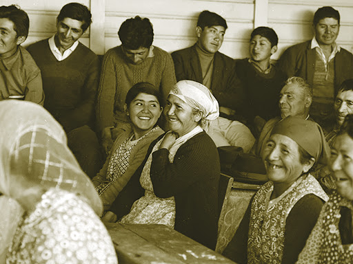

imagen

# [Analisis de base de datos del INE.](https://www.arcgis.com/apps/webappviewer/index.html?id=bc3cfbd4feec49699c11e813ae9a629f)

Para este analisis se bajaron los datos las entidades rurles definidas por el instituto nacional de estadistica para la aplicación del censo 2017.

Primero necesitamos importar las bases previamente descargadas.

```r
setwd("C:/Users/benja/OneDrive/Documentos/GitHub/pobreza_rural/docs/base_ine")
library(readr)
arauco <- read_delim("arauco.csv", ";", escape_double = FALSE, comment = "#", trim_ws = TRUE)
biobio <- read_delim("biobio.csv", ";", escape_double = FALSE, comment = "#", trim_ws = TRUE)
concepcion <- read_delim("concepcion.csv", ";", escape_double = FALSE, comment = "#", trim_ws = TRUE)
region_biobio<-rbind(arauco, biobio, concepcion)
save(region_biobio, file = "region_biobio.rda")
```

Podemos darnos cuentas que todas las variables tienen misma relacion con aquello que estan midiendo. Difieren en la provincia, ya que le hemos pedido especificamente una segmentacion de los datos segun la provincia en tres grandes conjuntos; Arauco, Biobio y Concepción. De esta manera aseguramos tener una unidad mas pequeña para asegurar aun mas la representatividad y luego unirlas todas en una sola gran base. Si le damos lectura a las variables podemos darnos cuentas que tenemos variables geograficas, demograficas, y de vivienda. Que nos sera util para analizar la pobreza de los habitantes en sectores rurales, asi como su perfilación demografica.

```r
names(region_biobio)
```

```
##  [1] "FID"
##  [2] "CODIGO REGION"
##  [3] "REGION"
##  [4] "CODIGO PROVINCIA"
##  [5] "PROVINCIA"
##  [6] "CODIGO COMUNA"
##  [7] "NOMBRE COMUNA"
##  [8] "DISTRITO"
##  [9] "AREA"
## [10] "Shape__Area"
## [11] "Shape__Length"
## [12] "CODIGO LOCALIDAD"
## [13] "LOCALIDAD"
## [14] "CODIGO ENTIDAD"
## [15] "ENTIDAD"
```

[output cut: 50 more lines]

Para proseguir con el analisis debemos transformar variables que por defecto el programa identifico como caracter, sin embargo, son numericas. Ya que Indeterminado debe ser modificado a un NA, que es como el programa indentifica los casos perdidos.

```r
region_biobio$`Total de Mujeres`<-as.numeric(region_biobio$`Total de Mujeres`)
region_biobio$`Total de Hombres`<-as.numeric(region_biobio$`Total de Hombres`)
region_biobio$`Total de personas de 0 a 5 años`<-as.numeric(region_biobio$`Total de personas de 0 a 5 años`)
region_biobio$`Total de personas de 6 a 14 años`<-as.numeric(region_biobio$`Total de personas de 6 a 14 años`)
region_biobio$`Total de personas de 15 a 64 años`<-as.numeric(region_biobio$`Total de personas de 15 a 64 años`)
region_biobio$`Total de personas de 65 y más años`<-as.numeric(region_biobio$`Total de personas de 65 y más años`)
region_biobio$`Total personas migrantes que residen habitualmente en el territorio nacional`<-as.numeric(region_biobio$`Total personas migrantes que residen habitualmente en el territorio nacional`)
region_biobio$`Total personas que se consideran pertenecientes a algún pueblo indígena u originario`<-as.numeric(region_biobio$`Total personas que se consideran pertenecientes a algún pueblo indígena u originario`)
```

Ademas corregimos las variables geograficas categoricas por factor

```r
region_biobio$REGION<-as.factor(region_biobio$REGION)
region_biobio$PROVINCIA<-as.factor(region_biobio$PROVINCIA)
region_biobio$`NOMBRE COMUNA`<-as.factor(region_biobio$`NOMBRE COMUNA`)
region_biobio$LOCALIDAD<-as.factor(region_biobio$LOCALIDAD)
region_biobio$ENTIDAD<-as.factor(region_biobio$ENTIDAD)
region_biobio$CATEGORIA<-as.factor(region_biobio$CATEGORIA)
```

# Datos

## Distribucion por Provincia, Comuna.

```r
table(region_biobio$PROVINCIA)
```

```
##
##     ARAUCO     BIOBÍO CONCEPCIÓN
##        476       1179        566
```

```r
table(region_biobio$`NOMBRE COMUNA`)
```

```
##
##         ALTO BIOBÍO              ANTUCO              ARAUCO             CABRERO
##                  35                  30                 113                  91
##              CAÑETE         CHIGUAYANTE          CONCEPCIÓN            CONTULMO
##                 148                   4                  67                  46
##             CORONEL         CURANILAHUE             FLORIDA             HUALPÉN
##                  37                  28                 119                  10
##             HUALQUI                LAJA                LEBU          LOS ÁLAMOS
##                  83                  71                  59                  33
##         LOS ÁNGELES                LOTA             MULCHÉN          NACIMIENTO
##                 373                   4                 105                  61
##             NEGRETE               PENCO             QUILACO            QUILLECO
##                  33                  19                  39                  47
## SAN PEDRO DE LA PAZ         SAN ROSENDO       SANTA BÁRBARA         SANTA JUANA
##                   3                  18                  67                  93
##          TALCAHUANO               TIRÚA                TOMÉ             TUCAPEL
##                   4                  49                 123                  52
##              YUMBEL
##                 157
```

```r
prop.table(table(region_biobio$PROVINCIA))*100
```

```
##
##     ARAUCO     BIOBÍO CONCEPCIÓN
##   21.43179   53.08420   25.48402
```

```r
prop.table(table(region_biobio$`NOMBRE COMUNA`))*100
```

```
##
##         ALTO BIOBÍO              ANTUCO              ARAUCO             CABRERO
##           1.5758667           1.3507429           5.0877983           4.0972535
##              CAÑETE         CHIGUAYANTE          CONCEPCIÓN            CONTULMO
##           6.6636650           0.1800991           3.0166592           2.0711391
##             CORONEL         CURANILAHUE             FLORIDA             HUALPÉN
##           1.6659163           1.2606934           5.3579469           0.4502476
##             HUALQUI                LAJA                LEBU          LOS ÁLAMOS
##           3.7370554           3.1967582           2.6564611           1.4858172
##         LOS ÁNGELES                LOTA             MULCHÉN          NACIMIENTO
##          16.7942368           0.1800991           4.7276002           2.7465106
##             NEGRETE               PENCO             QUILACO            QUILLECO
##           1.4858172           0.8554705           1.7559658           2.1161639
## SAN PEDRO DE LA PAZ         SAN ROSENDO       SANTA BÁRBARA         SANTA JUANA
##           0.1350743           0.8104457           3.0166592           4.1873030
##          TALCAHUANO               TIRÚA                TOMÉ             TUCAPEL
##           0.1800991           2.2062134           5.5380459           2.3412877
##              YUMBEL
##           7.0688879
```

```r
tabla_frecuencia_comuna<-data.frame(prop.table(table(region_biobio$`NOMBRE COMUNA`))*100)
summary(tabla_frecuencia_comuna)
```

```
##           Var1         Freq
##  ALTO BIOBÍO: 1   Min.   : 0.1351
##  ANTUCO     : 1   1st Qu.: 1.3507
##  ARAUCO     : 1   Median : 2.2062
##  CABRERO    : 1   Mean   : 3.0303
##  CAÑETE     : 1   3rd Qu.: 4.0973
##  CHIGUAYANTE: 1   Max.   :16.7942
##  (Other)    :27
```

```r
print(tabla_frecuencia_comuna[25,])
```

```
##                   Var1      Freq
## 25 SAN PEDRO DE LA PAZ 0.1350743
```

```r
print(tabla_frecuencia_comuna[17,])
```

```
##           Var1     Freq
## 17 LOS ÁNGELES 16.79424
```

Como podemos ver, la distribucion de las entidades rurales por provincia le correspone el 53,08% a la provicia del Biobío, un 25,48% a la de Concepción y un 21,43% a la provincia de Arauco. Si comparamos comunas, Los Angeles en la provicia del Biobío tiene el mayor porcentaje un 16,79%. Mientras que en la provincia de Concepción, la comuna de San Predro de la Paz tiene un 0.13%

## Categorias de las entidades rurales.

```r
table(region_biobio$CATEGORIA)
```

```
##
##                   Aldea   Asentamiento Pesquero              Campamento
##                      40                       7                       3
##                 Caserío      Comunidad Indígena Fundo-Estancia-Hacienda
##                     228                     123                     215
##           Indeterminada                   Otros         Parcela-Hijuela
##                     405                       6                    1141
##       Parcela de Agrado
##                      53
```

```r
prop.table(table(region_biobio$CATEGORIA))*100
```

```
##
##                   Aldea   Asentamiento Pesquero              Campamento
##               1.8009905               0.3151733               0.1350743
##                 Caserío      Comunidad Indígena Fundo-Estancia-Hacienda
##              10.2656461               5.5380459               9.6803242
##           Indeterminada                   Otros         Parcela-Hijuela
##              18.2350293               0.2701486              51.3732553
##       Parcela de Agrado
##               2.3863125
```

```r
tabla_frecuencia_categoria<-data.frame(prop.table(table(region_biobio$CATEGORIA))*100)
summary(tabla_frecuencia_categoria)
```

```
##                       Var1        Freq
##  Aldea                  :1   Min.   : 0.1351
##  Asentamiento Pesquero  :1   1st Qu.: 0.6866
##  Campamento             :1   Median : 3.9622
##  Caserío                :1   Mean   :10.0000
##  Comunidad Indígena     :1   3rd Qu.:10.1193
##  Fundo-Estancia-Hacienda:1   Max.   :51.3733
##  (Other)                :4
```

```r
print(tabla_frecuencia_categoria[10,])
```

```
##                 Var1     Freq
## 10 Parcela de Agrado 2.386312
```

```r
print(tabla_frecuencia_categoria[3,])
```

```
##         Var1      Freq
## 3 Campamento 0.1350743
```

En el caso de las categorias de las entidades rurales, encontramos que la mayor frecuencia de tipo parcela -Hijuela siendo el 51,37%. Por contastre, los campamentos son 0.13% de las entidades rurales.

## Datos demoraficos

### Población

```r
print("total de personas")
```

```
## [1] "total de personas"
```

```r
sum(region_biobio$`Número total de personas`, na.rm = T)
```

```
## [1] 177690
```

```r
print("total de hombres")
```

```
## [1] "total de hombres"
```

```r
sum(region_biobio$`Total de Hombres`, na.rm = T)
```

```
## [1] 90360
```

```r
print("total de mujeres")
```

```
## [1] "total de mujeres"
```

```r
sum(region_biobio$`Total de Mujeres`, na.rm = T)
```

```
## [1] 85188
```

```r
print("dispersión total")
```

```
## [1] "dispersión total"
```

```r
summary(region_biobio$`Número total de personas`)
```

```
##    Min. 1st Qu.  Median    Mean 3rd Qu.    Max.
##       0      18      39      80      92    1790
```

```r
print("dispersion por hombres")
```

```
## [1] "dispersion por hombres"
```

```r
summary(region_biobio$`Total de Hombres`)
```

```
##    Min. 1st Qu.  Median    Mean 3rd Qu.    Max.    NA's
##    0.00   11.00   22.00   43.01   50.00  926.00     120
```

```r
print("dispersion por mujer")
```

```
## [1] "dispersion por mujer"
```

```r
summary(region_biobio$`Total de Mujeres`)
```

```
##    Min. 1st Qu.  Median    Mean 3rd Qu.    Max.    NA's
##    0.00    9.00   20.00   40.55   46.00  864.00     120
```

```r
print("cortes por comuna")
```

```
## [1] "cortes por comuna"
```

```r
by(region_biobio$`Número total de personas`, region_biobio$`NOMBRE COMUNA`, FUN = summary)
```

```
## region_biobio$`NOMBRE COMUNA`: ALTO BIOBÍO
##    Min. 1st Qu.  Median    Mean 3rd Qu.    Max.
##    13.0    39.5    88.0   166.4   178.5   921.0
## ------------------------------------------------------------
## region_biobio$`NOMBRE COMUNA`: ANTUCO
##    Min. 1st Qu.  Median    Mean 3rd Qu.    Max.
##    0.00   12.25   31.00   66.53   91.75  490.00
## ------------------------------------------------------------
## region_biobio$`NOMBRE COMUNA`: ARAUCO
##    Min. 1st Qu.  Median    Mean 3rd Qu.    Max.
##    0.00   14.00   28.00   79.09   56.00 1790.00
## ------------------------------------------------------------
## region_biobio$`NOMBRE COMUNA`: CABRERO
##    Min. 1st Qu.  Median    Mean 3rd Qu.    Max.
##    0.00   18.50   42.00   77.02   88.00  440.00
## ------------------------------------------------------------
## region_biobio$`NOMBRE COMUNA`: CAÑETE
##    Min. 1st Qu.  Median    Mean 3rd Qu.    Max.
##    0.00   22.75   57.00  101.64  124.50  939.00
## ------------------------------------------------------------
## region_biobio$`NOMBRE COMUNA`: CHIGUAYANTE
##    Min. 1st Qu.  Median    Mean 3rd Qu.    Max.
##    0.00    7.50   15.00   18.75   26.25   45.00
## ------------------------------------------------------------
## region_biobio$`NOMBRE COMUNA`: CONCEPCIÓN
##    Min. 1st Qu.  Median    Mean 3rd Qu.    Max.
##    0.00   12.00   24.00   67.42   48.50  708.00
## ------------------------------------------------------------
## region_biobio$`NOMBRE COMUNA`: CONTULMO
##    Min. 1st Qu.  Median    Mean 3rd Qu.    Max.
##    0.00   23.25   52.50   64.57   73.50  363.00
## ------------------------------------------------------------
## region_biobio$`NOMBRE COMUNA`: CORONEL
##    Min. 1st Qu.  Median    Mean 3rd Qu.    Max.
##    0.00   24.00   44.00   86.16  104.00  744.00
## ------------------------------------------------------------
## region_biobio$`NOMBRE COMUNA`: CURANILAHUE
##    Min. 1st Qu.  Median    Mean 3rd Qu.    Max.
##    6.00   13.50   17.50   75.50   50.25  906.00
## ------------------------------------------------------------
```

[output cut: 76 more lines]

```
## region_biobio$`NOMBRE COMUNA`: TIRÚA
##    Min. 1st Qu.  Median    Mean 3rd Qu.    Max.
##     0.0    33.0   110.0   136.3   159.0   919.0
## ------------------------------------------------------------
## region_biobio$`NOMBRE COMUNA`: TOMÉ
##    Min. 1st Qu.  Median    Mean 3rd Qu.    Max.
##    0.00   11.00   25.00   43.95   56.00  364.00
## ------------------------------------------------------------
## region_biobio$`NOMBRE COMUNA`: TUCAPEL
##    Min. 1st Qu.  Median    Mean 3rd Qu.    Max.
##    0.00   12.00   23.00   43.21   45.00  788.00
## ------------------------------------------------------------
## region_biobio$`NOMBRE COMUNA`: YUMBEL
##    Min. 1st Qu.  Median    Mean 3rd Qu.    Max.
##    0.00   13.00   23.00   54.06   54.00  719.00
```

```r
print("por hombres")
```

```
## [1] "por hombres"
```

```r
by(region_biobio$`Total de Hombres`, region_biobio$`NOMBRE COMUNA`, FUN = summary)
```

```
## region_biobio$`NOMBRE COMUNA`: ALTO BIOBÍO
##    Min. 1st Qu.  Median    Mean 3rd Qu.    Max.
##    8.00   20.50   42.00   85.11   99.00  448.00
## ------------------------------------------------------------
## region_biobio$`NOMBRE COMUNA`: ANTUCO
##    Min. 1st Qu.  Median    Mean 3rd Qu.    Max.    NA's
##    0.00    7.00   17.00   38.24   55.00  240.00       5
## ------------------------------------------------------------
## region_biobio$`NOMBRE COMUNA`: ARAUCO
##    Min. 1st Qu.  Median    Mean 3rd Qu.    Max.    NA's
##    0.00    9.00   15.00   41.95   31.00  926.00       8
## ------------------------------------------------------------
## region_biobio$`NOMBRE COMUNA`: CABRERO
##    Min. 1st Qu.  Median    Mean 3rd Qu.    Max.    NA's
##    0.00   11.00   24.00   41.74   52.25  240.00       3
## ------------------------------------------------------------
## region_biobio$`NOMBRE COMUNA`: CAÑETE
##    Min. 1st Qu.  Median    Mean 3rd Qu.    Max.    NA's
##    0.00   13.00   30.50   52.11   63.00  453.00       4
## ------------------------------------------------------------
## region_biobio$`NOMBRE COMUNA`: CHIGUAYANTE
##    Min. 1st Qu.  Median    Mean 3rd Qu.    Max.    NA's
##     0.0     5.5    11.0    10.0    15.0    19.0       1
## ------------------------------------------------------------
## region_biobio$`NOMBRE COMUNA`: CONCEPCIÓN
##    Min. 1st Qu.  Median    Mean 3rd Qu.    Max.
##     0.0     6.0    14.0    33.7    25.5   344.0
## ------------------------------------------------------------
## region_biobio$`NOMBRE COMUNA`: CONTULMO
##    Min. 1st Qu.  Median    Mean 3rd Qu.    Max.
##    0.00   15.00   25.50   34.09   38.00  182.00
## ------------------------------------------------------------
## region_biobio$`NOMBRE COMUNA`: CORONEL
##    Min. 1st Qu.  Median    Mean 3rd Qu.    Max.    NA's
##    0.00   13.00   25.00   45.26   60.50  379.00       2
## ------------------------------------------------------------
## region_biobio$`NOMBRE COMUNA`: CURANILAHUE
##    Min. 1st Qu.  Median    Mean 3rd Qu.    Max.    NA's
##    5.00   10.00   17.00   50.05   32.75  467.00       6
## ------------------------------------------------------------
```

[output cut: 76 more lines]

```
## region_biobio$`NOMBRE COMUNA`: TIRÚA
##    Min. 1st Qu.  Median    Mean 3rd Qu.    Max.
##    0.00   18.00   57.00   68.94   81.00  451.00
## ------------------------------------------------------------
## region_biobio$`NOMBRE COMUNA`: TOMÉ
##    Min. 1st Qu.  Median    Mean 3rd Qu.    Max.    NA's
##    0.00    5.50   13.00   23.58   32.00  175.00       8
## ------------------------------------------------------------
## region_biobio$`NOMBRE COMUNA`: TUCAPEL
##    Min. 1st Qu.  Median    Mean 3rd Qu.    Max.    NA's
##    0.00    7.50   13.00   23.85   26.50  372.00       5
## ------------------------------------------------------------
## region_biobio$`NOMBRE COMUNA`: YUMBEL
##    Min. 1st Qu.  Median    Mean 3rd Qu.    Max.    NA's
##    0.00    8.00   13.50   29.88   32.00  345.00      15
```

```r
print("por mujeres")
```

```
## [1] "por mujeres"
```

```r
by(region_biobio$`Total de Mujeres`, region_biobio$`NOMBRE COMUNA`, FUN = summary)
```

```
## region_biobio$`NOMBRE COMUNA`: ALTO BIOBÍO
##    Min. 1st Qu.  Median    Mean 3rd Qu.    Max.
##    5.00   15.50   39.00   81.26   88.00  473.00
## ------------------------------------------------------------
## region_biobio$`NOMBRE COMUNA`: ANTUCO
##    Min. 1st Qu.  Median    Mean 3rd Qu.    Max.    NA's
##    0.00    5.00   15.00   38.04   53.00  250.00       5
## ------------------------------------------------------------
## region_biobio$`NOMBRE COMUNA`: ARAUCO
##    Min. 1st Qu.  Median    Mean 3rd Qu.    Max.    NA's
##     0.0     7.0    15.0    40.2    29.0   864.0       8
## ------------------------------------------------------------
## region_biobio$`NOMBRE COMUNA`: CABRERO
##    Min. 1st Qu.  Median    Mean 3rd Qu.    Max.    NA's
##    0.00    9.00   21.50   37.47   41.25  200.00       3
## ------------------------------------------------------------
## region_biobio$`NOMBRE COMUNA`: CAÑETE
##    Min. 1st Qu.  Median    Mean 3rd Qu.    Max.    NA's
##    0.00   10.75   28.00   51.74   63.75  486.00       4
## ------------------------------------------------------------
## region_biobio$`NOMBRE COMUNA`: CHIGUAYANTE
##    Min. 1st Qu.  Median    Mean 3rd Qu.    Max.    NA's
##    0.00    4.50    9.00   11.67   17.50   26.00       1
## ------------------------------------------------------------
## region_biobio$`NOMBRE COMUNA`: CONCEPCIÓN
##    Min. 1st Qu.  Median    Mean 3rd Qu.    Max.
##    0.00    4.50   12.00   33.72   23.00  364.00
## ------------------------------------------------------------
## region_biobio$`NOMBRE COMUNA`: CONTULMO
##    Min. 1st Qu.  Median    Mean 3rd Qu.    Max.
##    0.00    9.25   24.50   30.48   37.25  181.00
## ------------------------------------------------------------
## region_biobio$`NOMBRE COMUNA`: CORONEL
##    Min. 1st Qu.  Median    Mean 3rd Qu.    Max.    NA's
##    0.00   12.50   21.00   45.31   61.50  365.00       2
## ------------------------------------------------------------
## region_biobio$`NOMBRE COMUNA`: CURANILAHUE
##    Min. 1st Qu.  Median    Mean 3rd Qu.    Max.    NA's
##     4.0     6.0    11.5    42.5    24.0   439.0       6
## ------------------------------------------------------------
```

[output cut: 76 more lines]

```
## region_biobio$`NOMBRE COMUNA`: TIRÚA
##    Min. 1st Qu.  Median    Mean 3rd Qu.    Max.
##    0.00   15.00   54.00   67.37   80.00  468.00
## ------------------------------------------------------------
## region_biobio$`NOMBRE COMUNA`: TOMÉ
##    Min. 1st Qu.  Median    Mean 3rd Qu.    Max.    NA's
##    0.00    6.00   12.00   22.37   25.50  189.00       8
## ------------------------------------------------------------
## region_biobio$`NOMBRE COMUNA`: TUCAPEL
##    Min. 1st Qu.  Median    Mean 3rd Qu.    Max.    NA's
##    0.00    6.00   11.00   22.45   20.00  416.00       5
## ------------------------------------------------------------
## region_biobio$`NOMBRE COMUNA`: YUMBEL
##    Min. 1st Qu.  Median    Mean 3rd Qu.    Max.    NA's
##    0.00    7.00   11.00   28.25   27.75  374.00      15
```

```r
print("cortes por categoria")
```

```
## [1] "cortes por categoria"
```

```r
by(region_biobio$`Número total de personas`, region_biobio$CATEGORIA, FUN = summary)
```

```
## region_biobio$CATEGORIA: Aldea
##    Min. 1st Qu.  Median    Mean 3rd Qu.    Max.
##    90.0   328.8   470.0   538.0   710.8  1790.0
## ------------------------------------------------------------
## region_biobio$CATEGORIA: Asentamiento Pesquero
##    Min. 1st Qu.  Median    Mean 3rd Qu.    Max.
##    55.0    79.5    87.0   111.1   135.0   207.0
## ------------------------------------------------------------
## region_biobio$CATEGORIA: Campamento
##    Min. 1st Qu.  Median    Mean 3rd Qu.    Max.
##    2.00    3.50    5.00   13.33   19.00   33.00
## ------------------------------------------------------------
## region_biobio$CATEGORIA: Caserío
##    Min. 1st Qu.  Median    Mean 3rd Qu.    Max.
##     0.0    48.0    86.5   120.3   158.8  1178.0
## ------------------------------------------------------------
## region_biobio$CATEGORIA: Comunidad Indígena
##    Min. 1st Qu.  Median    Mean 3rd Qu.    Max.
##     0.0    38.5    83.0   125.8   158.5   919.0
## ------------------------------------------------------------
## region_biobio$CATEGORIA: Fundo-Estancia-Hacienda
##    Min. 1st Qu.  Median    Mean 3rd Qu.    Max.
##    0.00    0.00   15.00   23.05   28.00  243.00
## ------------------------------------------------------------
## region_biobio$CATEGORIA: Indeterminada
##    Min. 1st Qu.  Median    Mean 3rd Qu.    Max.
##     5.0    17.0    28.0    50.9    56.0   561.0
## ------------------------------------------------------------
## region_biobio$CATEGORIA: Otros
##    Min. 1st Qu.  Median    Mean 3rd Qu.    Max.
##   0.000   0.000   4.000   7.333   8.750  27.000
## ------------------------------------------------------------
## region_biobio$CATEGORIA: Parcela-Hijuela
##    Min. 1st Qu.  Median    Mean 3rd Qu.    Max.
##    0.00   18.00   39.00   70.98   85.00 1009.00
## ------------------------------------------------------------
## region_biobio$CATEGORIA: Parcela de Agrado
##    Min. 1st Qu.  Median    Mean 3rd Qu.    Max.
##     0.0    32.0    69.0   110.6   149.0   662.0
```

```r
print("por hombre")
```

```
## [1] "por hombre"
```

```r
by(region_biobio$`Total de Hombres`, region_biobio$CATEGORIA, FUN = summary)
```

```
## region_biobio$CATEGORIA: Aldea
##    Min. 1st Qu.  Median    Mean 3rd Qu.    Max.
##    43.0   165.2   227.5   263.3   344.2   926.0
## ------------------------------------------------------------
## region_biobio$CATEGORIA: Asentamiento Pesquero
##    Min. 1st Qu.  Median    Mean 3rd Qu.    Max.
##   28.00   41.50   46.00   56.29   65.50  106.00
## ------------------------------------------------------------
## region_biobio$CATEGORIA: Campamento
##    Min. 1st Qu.  Median    Mean 3rd Qu.    Max.    NA's
##       5       5       5       5       5       5       2
## ------------------------------------------------------------
## region_biobio$CATEGORIA: Caserío
##    Min. 1st Qu.  Median    Mean 3rd Qu.    Max.    NA's
##    0.00   25.00   44.00   64.23   81.00  918.00      10
## ------------------------------------------------------------
## region_biobio$CATEGORIA: Comunidad Indígena
##    Min. 1st Qu.  Median    Mean 3rd Qu.    Max.    NA's
##    0.00   20.25   40.50   63.60   78.75  451.00       1
## ------------------------------------------------------------
## region_biobio$CATEGORIA: Fundo-Estancia-Hacienda
##    Min. 1st Qu.  Median    Mean 3rd Qu.    Max.    NA's
##    0.00    0.00    8.00   12.75   15.00  126.00      14
## ------------------------------------------------------------
## region_biobio$CATEGORIA: Indeterminada
##    Min. 1st Qu.  Median    Mean 3rd Qu.    Max.    NA's
##    5.00    9.50   16.00   27.91   32.00  294.00      30
## ------------------------------------------------------------
## region_biobio$CATEGORIA: Otros
##    Min. 1st Qu.  Median    Mean 3rd Qu.    Max.    NA's
##    0.00    0.00    0.00    2.25    2.25    9.00       2
## ------------------------------------------------------------
## region_biobio$CATEGORIA: Parcela-Hijuela
##    Min. 1st Qu.  Median    Mean 3rd Qu.    Max.    NA's
##    0.00   11.00   22.00   38.63   47.00  500.00      60
## ------------------------------------------------------------
## region_biobio$CATEGORIA: Parcela de Agrado
##    Min. 1st Qu.  Median    Mean 3rd Qu.    Max.    NA's
##    0.00   16.75   32.00   55.29   71.75  334.00       1
```

```r
print("por mujer")
```

```
## [1] "por mujer"
```

```r
by(region_biobio$`Total de Mujeres`, region_biobio$CATEGORIA, FUN = summary)
```

```
## region_biobio$CATEGORIA: Aldea
##    Min. 1st Qu.  Median    Mean 3rd Qu.    Max.
##    47.0   175.5   238.5   274.8   364.2   864.0
## ------------------------------------------------------------
## region_biobio$CATEGORIA: Asentamiento Pesquero
##    Min. 1st Qu.  Median    Mean 3rd Qu.    Max.
##   27.00   38.00   41.00   54.86   69.50  101.00
## ------------------------------------------------------------
## region_biobio$CATEGORIA: Campamento
##    Min. 1st Qu.  Median    Mean 3rd Qu.    Max.    NA's
##       0       0       0       0       0       0       2
## ------------------------------------------------------------
## region_biobio$CATEGORIA: Caserío
##    Min. 1st Qu.  Median    Mean 3rd Qu.    Max.    NA's
##    0.00   25.00   44.00   59.98   81.00  356.00      10
## ------------------------------------------------------------
## region_biobio$CATEGORIA: Comunidad Indígena
##    Min. 1st Qu.  Median    Mean 3rd Qu.    Max.    NA's
##    0.00   18.00   44.00   63.14   79.75  468.00       1
## ------------------------------------------------------------
## region_biobio$CATEGORIA: Fundo-Estancia-Hacienda
##    Min. 1st Qu.  Median    Mean 3rd Qu.    Max.    NA's
##    0.00    0.00    7.00   11.25   14.00  117.00      14
## ------------------------------------------------------------
## region_biobio$CATEGORIA: Indeterminada
##    Min. 1st Qu.  Median    Mean 3rd Qu.    Max.    NA's
##    4.00    8.00   14.00   25.32   27.00  267.00      30
## ------------------------------------------------------------
## region_biobio$CATEGORIA: Otros
##    Min. 1st Qu.  Median    Mean 3rd Qu.    Max.    NA's
##       0       0       0       0       0       0       2
## ------------------------------------------------------------
## region_biobio$CATEGORIA: Parcela-Hijuela
##    Min. 1st Qu.  Median    Mean 3rd Qu.    Max.    NA's
##    0.00    9.00   20.00   35.43   42.00  509.00      60
## ------------------------------------------------------------
## region_biobio$CATEGORIA: Parcela de Agrado
##    Min. 1st Qu.  Median    Mean 3rd Qu.    Max.    NA's
##    0.00   17.75   38.50   57.25   79.75  328.00       1
```

### Migración

```r
sum(region_biobio$`Total personas migrantes que residen habitualmente en el territorio nacional`, na.rm = T)
```

```
## [1] 229
```

```r
summary(region_biobio$`Total personas migrantes que residen habitualmente en el territorio nacional`)
```

```
##    Min. 1st Qu.  Median    Mean 3rd Qu.    Max.    NA's
##  0.0000  0.0000  0.0000  0.1246  0.0000 16.0000     383
```

```r
table(region_biobio$`Total personas migrantes que residen habitualmente en el territorio nacional`)
```

```
##
##    0    4    5    6    7    8    9   10   15   16
## 1801   14    7    3    4    4    1    2    1    1
```

### Poblacion Indigena.

```r
library(dplyr)
sum(region_biobio$`Total personas que se consideran pertenecientes a algún pueblo indígena u originario`, na.rm = T)
```

```
## [1] 30043
```

```r
summary(region_biobio$`Total personas que se consideran pertenecientes a algún pueblo indígena u originario`)
```

```
##    Min. 1st Qu.  Median    Mean 3rd Qu.    Max.    NA's
##       0       0       5      20      15     773     719
```

```r
table(region_biobio$`Total personas que se consideran pertenecientes a algún pueblo indígena u originario`)
```

```
##
##   0   4   5   6   7   8   9  10  11  12  13  14  15  16  17  18  19  20  21  22
## 651  87  74  52  52  49  33  24  23  27  20  28  19  13  16  16  14  15   8  12
##  23  24  25  26  27  28  29  30  31  32  33  34  35  36  37  38  39  40  41  42
##   9   5   4   6   8   2   6   7   8   5   8   5   6   5   5   6   4   1   5   4
##  43  44  45  46  47  48  50  51  52  53  54  55  56  57  58  59  60  62  63  64
##   3   1   3   1   6   2   4   1   2   3   3   2   3   3   1   2   2   1   1   2
##  65  66  67  68  69  70  71  72  73  75  78  79  80  81  85  86  88  89  90  91
##   2   2   1   1   1   2   2   1   2   4   2   2   2   1   2   2   1   1   1   2
##  92  94  97  98  99 100 102 104 105 106 107 108 111 112 114 119 122 128 130 131
##   1   3   1   3   1   3   3   3   1   1   1   1   1   2   1   1   2   1   1   1
## 132 136 139 143 146 148 155 156 163 169 170 176 178 195 206 207 222 236 241 248
##   2   1   1   1   1   3   1   2   1   1   2   2   1   1   2   1   1   2   1   1
## 249 250 251 273 276 280 288 303 312 327 346 361 377 407 442 446 502 535 624 773
##   1   1   1   1   1   1   1   1   1   1   1   1   1   1   1   1   1   1   1   1
```

```r
indigenas<-filter(region_biobio, region_biobio$`Total personas que se consideran pertenecientes a algún pueblo indígena u originario`>=4)
prop.table(table(indigenas$`NOMBRE COMUNA`))*100
```

```
##
##         ALTO BIOBÍO              ANTUCO              ARAUCO             CABRERO
##           4.1128085           1.0575793           6.3454759           4.1128085
##              CAÑETE         CHIGUAYANTE          CONCEPCIÓN            CONTULMO
##          12.9259694           0.1175088           1.0575793           3.0552291
##             CORONEL         CURANILAHUE             FLORIDA             HUALPÉN
##           1.9976498           1.0575793           2.4676851           0.2350176
##             HUALQUI                LAJA                LEBU          LOS ÁLAMOS
##           1.9976498           2.7027027           2.9377203           2.8202115
##         LOS ÁNGELES                LOTA             MULCHÉN          NACIMIENTO
##          20.7990599           0.2350176           4.4653349           1.6451234
##             NEGRETE               PENCO             QUILACO            QUILLECO
##           2.1151586           0.0000000           1.9976498           1.4101058
## SAN PEDRO DE LA PAZ         SAN ROSENDO       SANTA BÁRBARA         SANTA JUANA
##           0.1175088           0.2350176           3.9952996           1.8801410
##          TALCAHUANO               TIRÚA                TOMÉ             TUCAPEL
##           0.2350176           5.6404230           3.4077556           0.7050529
##              YUMBEL
##           2.1151586
```

```r
prop.table(table(indigenas$CATEGORIA))*100
```

```
##
##                   Aldea   Asentamiento Pesquero              Campamento
##               4.2303173               0.2350176               0.0000000
##                 Caserío      Comunidad Indígena Fundo-Estancia-Hacienda
##              15.1586369              13.9835488               2.8202115
##           Indeterminada                   Otros         Parcela-Hijuela
##              16.9212691               0.1175088              44.1833137
##       Parcela de Agrado
##               2.3501763
```

```r
sum(indigenas$`Total de Hombres`, na.rm = T)
```

```
## [1] 62554
```

```r
sum(indigenas$`Total de Mujeres`, na.rm = T)
```

```
## [1] 59685
```

### Extra

```r
library(dplyr)
sin_poblacion<-filter(region_biobio, region_biobio$`Número total de personas`==0)
table(sin_poblacion$NOMBRE.COMUNA)
```

```
## < table of extent 0 >
```

```r
table(sin_poblacion$CATEGORIA)
```

```
##
##                   Aldea   Asentamiento Pesquero              Campamento
##                       0                       0                       0
##                 Caserío      Comunidad Indígena Fundo-Estancia-Hacienda
##                       1                       1                      60
##           Indeterminada                   Otros         Parcela-Hijuela
##                       0                       3                      65
##       Parcela de Agrado
##                       2
```

## Datos sobre vivienda

### Viviendas y hogares.

Si entendemos las viviendas como la unidad donde un individuo o grupo humano pude vivir, damos cuenta que no se esta ocupando en su totalidad este recurso, ya que del total de 78739 viviendas solo estan ocupadas y con moradores 59072, lo cual nos deja 19667 viviendas desocupas o sin moradores. Sin embargo, tenemos una catidad de 59477 hogares, evidenciamos que existen 405 hogares que no tienen un vivienda propia.

```r
total_viviendas<-sum(region_biobio$`Total viviendas`)
print(total_viviendas)
```

```
## [1] 78739
```

```r
summary(region_biobio$`Total viviendas`)
```

```
##    Min. 1st Qu.  Median    Mean 3rd Qu.    Max.
##    1.00   10.00   20.00   35.45   43.00  611.00
```

```r
viviendas_ocupadas<-sum(region_biobio$`Total viviendas ocupadas con moradores presentes`)
print(viviendas_ocupadas)
```

```
## [1] 59072
```

```r
summary(region_biobio$`Total viviendas ocupadas con moradores presentes`)
```

```
##    Min. 1st Qu.  Median    Mean 3rd Qu.    Max.
##     0.0     6.0    14.0    26.6    31.0   525.0
```

```r
total_hogares<-sum(region_biobio$`Cantidad de hogares`)
print(total_hogares)
```

```
## [1] 59477
```

```r
summary(region_biobio$`Cantidad de hogares`)
```

```
##    Min. 1st Qu.  Median    Mean 3rd Qu.    Max.
##    0.00    7.00   14.00   26.78   31.00  530.00
```

```r
viviendas_desocupadas<-c(total_viviendas-viviendas_ocupadas)
print(viviendas_desocupadas)
```

```
## [1] 19667
```

```r
sin_vivienda<-c(total_hogares-viviendas_ocupadas)
print(sin_vivienda)
```

```
## [1] 405
```

### Viviendas y hogares por comuna y categoria de entidad.

```r
print("total de viviendas por comuna")
```

```
## [1] "total de viviendas por comuna"
```

```r
by(region_biobio$`Total viviendas`, region_biobio$`NOMBRE COMUNA`, sum)
```

```
## region_biobio$`NOMBRE COMUNA`: ALTO BIOBÍO
## [1] 2094
## ------------------------------------------------------------
## region_biobio$`NOMBRE COMUNA`: ANTUCO
## [1] 1147
## ------------------------------------------------------------
## region_biobio$`NOMBRE COMUNA`: ARAUCO
## [1] 3718
## ------------------------------------------------------------
## region_biobio$`NOMBRE COMUNA`: CABRERO
## [1] 3222
## ------------------------------------------------------------
## region_biobio$`NOMBRE COMUNA`: CAÑETE
## [1] 5730
## ------------------------------------------------------------
## region_biobio$`NOMBRE COMUNA`: CHIGUAYANTE
## [1] 32
## ------------------------------------------------------------
## region_biobio$`NOMBRE COMUNA`: CONCEPCIÓN
## [1] 1711
## ------------------------------------------------------------
## region_biobio$`NOMBRE COMUNA`: CONTULMO
## [1] 1466
## ------------------------------------------------------------
## region_biobio$`NOMBRE COMUNA`: CORONEL
## [1] 1434
## ------------------------------------------------------------
## region_biobio$`NOMBRE COMUNA`: CURANILAHUE
## [1] 1001
## ------------------------------------------------------------
## region_biobio$`NOMBRE COMUNA`: FLORIDA
## [1] 3416
## ------------------------------------------------------------
## region_biobio$`NOMBRE COMUNA`: HUALPÉN
## [1] 248
## ------------------------------------------------------------
## region_biobio$`NOMBRE COMUNA`: HUALQUI
## [1] 2020
## ------------------------------------------------------------
## region_biobio$`NOMBRE COMUNA`: LAJA
```

[output cut: 43 more lines]

```
## ------------------------------------------------------------
## region_biobio$`NOMBRE COMUNA`: TALCAHUANO
## [1] 133
## ------------------------------------------------------------
## region_biobio$`NOMBRE COMUNA`: TIRÚA
## [1] 2443
## ------------------------------------------------------------
## region_biobio$`NOMBRE COMUNA`: TOMÉ
## [1] 3068
## ------------------------------------------------------------
## region_biobio$`NOMBRE COMUNA`: TUCAPEL
## [1] 1299
## ------------------------------------------------------------
## region_biobio$`NOMBRE COMUNA`: YUMBEL
## [1] 5346
```

```r
print("total de vivienad por categoria")
```

```
## [1] "total de vivienad por categoria"
```

```r
by(region_biobio$`Total viviendas`, region_biobio$CATEGORIA, sum)
```

```
## region_biobio$CATEGORIA: Aldea
## [1] 8402
## ------------------------------------------------------------
## region_biobio$CATEGORIA: Asentamiento Pesquero
## [1] 340
## ------------------------------------------------------------
## region_biobio$CATEGORIA: Campamento
## [1] 3
## ------------------------------------------------------------
## region_biobio$CATEGORIA: Caserío
## [1] 11075
## ------------------------------------------------------------
## region_biobio$CATEGORIA: Comunidad Indígena
## [1] 5339
## ------------------------------------------------------------
## region_biobio$CATEGORIA: Fundo-Estancia-Hacienda
## [1] 2117
## ------------------------------------------------------------
## region_biobio$CATEGORIA: Indeterminada
## [1] 10691
## ------------------------------------------------------------
## region_biobio$CATEGORIA: Otros
## [1] 6
## ------------------------------------------------------------
## region_biobio$CATEGORIA: Parcela-Hijuela
## [1] 38480
## ------------------------------------------------------------
## region_biobio$CATEGORIA: Parcela de Agrado
## [1] 2286
```

```r
print("total de viviendas ocupadas por comuna")
```

```
## [1] "total de viviendas ocupadas por comuna"
```

```r
by(region_biobio$`Total viviendas ocupadas con moradores presentes`, region_biobio$`NOMBRE COMUNA`, sum)
```

```
## region_biobio$`NOMBRE COMUNA`: ALTO BIOBÍO
## [1] 1716
## ------------------------------------------------------------
## region_biobio$`NOMBRE COMUNA`: ANTUCO
## [1] 721
## ------------------------------------------------------------
## region_biobio$`NOMBRE COMUNA`: ARAUCO
## [1] 2929
## ------------------------------------------------------------
## region_biobio$`NOMBRE COMUNA`: CABRERO
## [1] 2449
## ------------------------------------------------------------
## region_biobio$`NOMBRE COMUNA`: CAÑETE
## [1] 4793
## ------------------------------------------------------------
## region_biobio$`NOMBRE COMUNA`: CHIGUAYANTE
## [1] 21
## ------------------------------------------------------------
## region_biobio$`NOMBRE COMUNA`: CONCEPCIÓN
## [1] 1430
## ------------------------------------------------------------
## region_biobio$`NOMBRE COMUNA`: CONTULMO
## [1] 1010
## ------------------------------------------------------------
## region_biobio$`NOMBRE COMUNA`: CORONEL
## [1] 1034
## ------------------------------------------------------------
## region_biobio$`NOMBRE COMUNA`: CURANILAHUE
## [1] 739
## ------------------------------------------------------------
## region_biobio$`NOMBRE COMUNA`: FLORIDA
## [1] 2183
## ------------------------------------------------------------
## region_biobio$`NOMBRE COMUNA`: HUALPÉN
## [1] 225
## ------------------------------------------------------------
## region_biobio$`NOMBRE COMUNA`: HUALQUI
## [1] 1261
## ------------------------------------------------------------
## region_biobio$`NOMBRE COMUNA`: LAJA
```

[output cut: 43 more lines]

```
## ------------------------------------------------------------
## region_biobio$`NOMBRE COMUNA`: TALCAHUANO
## [1] 123
## ------------------------------------------------------------
## region_biobio$`NOMBRE COMUNA`: TIRÚA
## [1] 2060
## ------------------------------------------------------------
## region_biobio$`NOMBRE COMUNA`: TOMÉ
## [1] 1841
## ------------------------------------------------------------
## region_biobio$`NOMBRE COMUNA`: TUCAPEL
## [1] 863
## ------------------------------------------------------------
## region_biobio$`NOMBRE COMUNA`: YUMBEL
## [1] 3196
```

```r
print("total de viviedas ocupadas por categoria")
```

```
## [1] "total de viviedas ocupadas por categoria"
```

```r
by(region_biobio$`Total viviendas ocupadas con moradores presentes`, region_biobio$CATEGORIA, sum)
```

```
## region_biobio$CATEGORIA: Aldea
## [1] 6864
## ------------------------------------------------------------
## region_biobio$CATEGORIA: Asentamiento Pesquero
## [1] 284
## ------------------------------------------------------------
## region_biobio$CATEGORIA: Campamento
## [1] 0
## ------------------------------------------------------------
## region_biobio$CATEGORIA: Caserío
## [1] 8682
## ------------------------------------------------------------
## region_biobio$CATEGORIA: Comunidad Indígena
## [1] 4596
## ------------------------------------------------------------
## region_biobio$CATEGORIA: Fundo-Estancia-Hacienda
## [1] 1575
## ------------------------------------------------------------
## region_biobio$CATEGORIA: Indeterminada
## [1] 7231
## ------------------------------------------------------------
## region_biobio$CATEGORIA: Otros
## [1] 0
## ------------------------------------------------------------
## region_biobio$CATEGORIA: Parcela-Hijuela
## [1] 28069
## ------------------------------------------------------------
## region_biobio$CATEGORIA: Parcela de Agrado
## [1] 1771
```

```r
print("cantidad de hogares por comuna")
```

```
## [1] "cantidad de hogares por comuna"
```

```r
by(region_biobio$`Cantidad de hogares`, region_biobio$`NOMBRE COMUNA`, sum)
```

```
## region_biobio$`NOMBRE COMUNA`: ALTO BIOBÍO
## [1] 1736
## ------------------------------------------------------------
## region_biobio$`NOMBRE COMUNA`: ANTUCO
## [1] 723
## ------------------------------------------------------------
## region_biobio$`NOMBRE COMUNA`: ARAUCO
## [1] 2953
## ------------------------------------------------------------
## region_biobio$`NOMBRE COMUNA`: CABRERO
## [1] 2471
## ------------------------------------------------------------
## region_biobio$`NOMBRE COMUNA`: CAÑETE
## [1] 4833
## ------------------------------------------------------------
## region_biobio$`NOMBRE COMUNA`: CHIGUAYANTE
## [1] 21
## ------------------------------------------------------------
## region_biobio$`NOMBRE COMUNA`: CONCEPCIÓN
## [1] 1439
## ------------------------------------------------------------
## region_biobio$`NOMBRE COMUNA`: CONTULMO
## [1] 1021
## ------------------------------------------------------------
## region_biobio$`NOMBRE COMUNA`: CORONEL
## [1] 1054
## ------------------------------------------------------------
## region_biobio$`NOMBRE COMUNA`: CURANILAHUE
## [1] 740
## ------------------------------------------------------------
## region_biobio$`NOMBRE COMUNA`: FLORIDA
## [1] 2188
## ------------------------------------------------------------
## region_biobio$`NOMBRE COMUNA`: HUALPÉN
## [1] 225
## ------------------------------------------------------------
## region_biobio$`NOMBRE COMUNA`: HUALQUI
## [1] 1270
## ------------------------------------------------------------
## region_biobio$`NOMBRE COMUNA`: LAJA
```

[output cut: 43 more lines]

```
## ------------------------------------------------------------
## region_biobio$`NOMBRE COMUNA`: TALCAHUANO
## [1] 123
## ------------------------------------------------------------
## region_biobio$`NOMBRE COMUNA`: TIRÚA
## [1] 2089
## ------------------------------------------------------------
## region_biobio$`NOMBRE COMUNA`: TOMÉ
## [1] 1847
## ------------------------------------------------------------
## region_biobio$`NOMBRE COMUNA`: TUCAPEL
## [1] 873
## ------------------------------------------------------------
## region_biobio$`NOMBRE COMUNA`: YUMBEL
## [1] 3215
```

```r
print("cantidad de hogares por categorias")
```

```
## [1] "cantidad de hogares por categorias"
```

```r
by(region_biobio$`Cantidad de hogares`, region_biobio$CATEGORIA, sum)
```

```
## region_biobio$CATEGORIA: Aldea
## [1] 6929
## ------------------------------------------------------------
## region_biobio$CATEGORIA: Asentamiento Pesquero
## [1] 286
## ------------------------------------------------------------
## region_biobio$CATEGORIA: Campamento
## [1] 0
## ------------------------------------------------------------
## region_biobio$CATEGORIA: Caserío
## [1] 8738
## ------------------------------------------------------------
## region_biobio$CATEGORIA: Comunidad Indígena
## [1] 4651
## ------------------------------------------------------------
## region_biobio$CATEGORIA: Fundo-Estancia-Hacienda
## [1] 1587
## ------------------------------------------------------------
## region_biobio$CATEGORIA: Indeterminada
## [1] 7270
## ------------------------------------------------------------
## region_biobio$CATEGORIA: Otros
## [1] 0
## ------------------------------------------------------------
## region_biobio$CATEGORIA: Parcela-Hijuela
## [1] 28236
## ------------------------------------------------------------
## region_biobio$CATEGORIA: Parcela de Agrado
## [1] 1780
```

### Tipos de vivienda

```r
print("Cantidad de viviendas tipo casa")
```

```
## [1] "Cantidad de viviendas tipo casa"
```

```r
sum(region_biobio$`Cantidad de viviendas tipo casa`)
```

```
## [1] 75123
```

```r
print("Cantidad de viviendas tipo departamento en edificio")
```

```
## [1] "Cantidad de viviendas tipo departamento en edificio"
```

```r
sum(region_biobio$`Cantidad de viviendas tipo departamento en edificio`)
```

```
## [1] 11
```

```r
print("Cantidad de viviendas tipo vivienda tradicional indígena (ruka, pae pae u otras)")
```

```
## [1] "Cantidad de viviendas tipo vivienda tradicional indígena (ruka, pae pae u otras)"
```

```r
sum(region_biobio$`Cantidad de viviendas tipo vivienda tradicional indígena (ruka, pae pae u otras)`)
```

```
## [1] 115
```

```r
print("Cantidad de viviendas tipo pieza en casa antigua o en conventillo")
```

```
## [1] "Cantidad de viviendas tipo pieza en casa antigua o en conventillo"
```

```r
sum(region_biobio$`Cantidad de viviendas tipo pieza en casa antigua o en conventillo`)
```

```
## [1] 179
```

```r
print("Cantidad de viviendas tipo mediagua, mejora, rancho o choza")
```

```
## [1] "Cantidad de viviendas tipo mediagua, mejora, rancho o choza"
```

```r
sum(region_biobio$`Cantidad de viviendas tipo mediagua, mejora, rancho o choza`)
```

```
## [1] 2753
```

```r
print("Cantidad de viviendas tipo móvil (carpa, casa rodante o similar)")
```

```
## [1] "Cantidad de viviendas tipo móvil (carpa, casa rodante o similar)"
```

```r
sum(region_biobio$`Cantidad de viviendas tipo móvil (carpa, casa rodante o similar)`)
```

```
## [1] 20
```

```r
print("Cantidad de viviendas tipo otro tipo de vivienda particular")
```

```
## [1] "Cantidad de viviendas tipo otro tipo de vivienda particular"
```

```r
sum(region_biobio$`Cantidad de viviendas tipo otro tipo de vivienda particular`)
```

```
## [1] 405
```

### Analisis de tipo de vivienda casa.

```r
by(region_biobio$`Cantidad de viviendas tipo casa`, region_biobio$CATEGORIA, sum)
```

```
## region_biobio$CATEGORIA: Aldea
## [1] 8106
## ------------------------------------------------------------
## region_biobio$CATEGORIA: Asentamiento Pesquero
## [1] 330
## ------------------------------------------------------------
## region_biobio$CATEGORIA: Campamento
## [1] 0
## ------------------------------------------------------------
## region_biobio$CATEGORIA: Caserío
## [1] 10625
## ------------------------------------------------------------
## region_biobio$CATEGORIA: Comunidad Indígena
## [1] 5013
## ------------------------------------------------------------
## region_biobio$CATEGORIA: Fundo-Estancia-Hacienda
## [1] 2009
## ------------------------------------------------------------
## region_biobio$CATEGORIA: Indeterminada
## [1] 10004
## ------------------------------------------------------------
## region_biobio$CATEGORIA: Otros
## [1] 3
## ------------------------------------------------------------
## region_biobio$CATEGORIA: Parcela-Hijuela
## [1] 36794
## ------------------------------------------------------------
## region_biobio$CATEGORIA: Parcela de Agrado
## [1] 2239
```

```r
by(region_biobio$`Cantidad de viviendas tipo casa`, region_biobio$CATEGORIA, summary)
```

```
## region_biobio$CATEGORIA: Aldea
##    Min. 1st Qu.  Median    Mean 3rd Qu.    Max.
##    30.0   107.8   186.5   202.7   248.5   571.0
## ------------------------------------------------------------
## region_biobio$CATEGORIA: Asentamiento Pesquero
##    Min. 1st Qu.  Median    Mean 3rd Qu.    Max.
##   21.00   37.00   41.00   47.14   59.00   76.00
## ------------------------------------------------------------
## region_biobio$CATEGORIA: Campamento
##    Min. 1st Qu.  Median    Mean 3rd Qu.    Max.
##       0       0       0       0       0       0
## ------------------------------------------------------------
## region_biobio$CATEGORIA: Caserío
##    Min. 1st Qu.  Median    Mean 3rd Qu.    Max.
##    0.00   21.00   36.50   46.60   59.25  231.00
## ------------------------------------------------------------
## region_biobio$CATEGORIA: Comunidad Indígena
##    Min. 1st Qu.  Median    Mean 3rd Qu.    Max.
##    1.00   12.50   28.00   40.76   55.50  332.00
## ------------------------------------------------------------
## region_biobio$CATEGORIA: Fundo-Estancia-Hacienda
##    Min. 1st Qu.  Median    Mean 3rd Qu.    Max.
##   0.000   2.500   6.000   9.344  11.000  96.000
## ------------------------------------------------------------
## region_biobio$CATEGORIA: Indeterminada
##    Min. 1st Qu.  Median    Mean 3rd Qu.    Max.
##     3.0     9.0    15.0    24.7    30.0   233.0
## ------------------------------------------------------------
## region_biobio$CATEGORIA: Otros
##    Min. 1st Qu.  Median    Mean 3rd Qu.    Max.
##     0.0     0.0     0.5     0.5     1.0     1.0
## ------------------------------------------------------------
## region_biobio$CATEGORIA: Parcela-Hijuela
##    Min. 1st Qu.  Median    Mean 3rd Qu.    Max.
##    0.00    9.00   19.00   32.25   40.00  318.00
## ------------------------------------------------------------
## region_biobio$CATEGORIA: Parcela de Agrado
##    Min. 1st Qu.  Median    Mean 3rd Qu.    Max.
##    1.00   17.00   29.00   42.25   52.00  249.00
```

```r
cor(region_biobio$`Cantidad de viviendas tipo casa`, region_biobio$`Total de Hombres`, use = "na.or.complete")
```

```
## [1] 0.9103897
```

```r
cor(region_biobio$`Cantidad de viviendas tipo casa`, region_biobio$`Total de Mujeres`, use = "na.or.complete")
```

```
## [1] 0.9483322
```

```r
cor(region_biobio$`Cantidad de viviendas tipo casa`, region_biobio$`Total personas que se consideran pertenecientes a algún pueblo indígena u originario`, use = "na.or.complete")
```

```
## [1] 0.458254
```

## Analisis de acceso al agua.

```r
print("Cantidad de viviendas con origen del agua por red pública")
```

```
## [1] "Cantidad de viviendas con origen del agua por red pública"
```

```r
sum(region_biobio$`Cantidad de viviendas con origen del agua por red pública`)
```

```
## [1] 18988
```

```r
print("Cantidad de viviendas con origen del agua por pozo o noria")
```

```
## [1] "Cantidad de viviendas con origen del agua por pozo o noria"
```

```r
sum(region_biobio$`Cantidad de viviendas con origen del agua por pozo o noria`)
```

```
## [1] 25007
```

```r
print("Cantidad de viviendas con origen del agua por camión aljibe")
```

```
## [1] "Cantidad de viviendas con origen del agua por camión aljibe"
```

```r
sum(region_biobio$`Cantidad de viviendas con origen del agua por camión aljibe`)
```

```
## [1] 3873
```

```r
print("Cantidad de viviendas con origen del agua por río, vertiente, estero, canal, lago, etc.")
```

```
## [1] "Cantidad de viviendas con origen del agua por río, vertiente, estero, canal, lago, etc."
```

```r
sum(region_biobio$`Cantidad de viviendas con origen del agua por río, vertiente, estero, canal, lago, etc.`)
```

```
## [1] 10741
```